# Kennissessie R en GIS

15 februari 2018

## Gemeente Den Haag

Situatie nu:

- Lokale opslag
- SPSS
- ArcGIS

-> automatiseren

- Data Lake
- Rstudio Server
- & iets van een BI-tool

## Waarom?

- Omgevingswet
- "*Met de Omgevingswet wil de overheid de regels voor ruimtelijke ontwikkeling vereenvoudigen en samenvoegen. … Naar verwachting treedt de Omgevingswet in 2021 in werking.*"
  - bron: www.rijksoverheid.nl
- Alle (niet privacy-gevoelige) data moet openbaar worden

## Hoe doe je dat?

- csv-tje op opendata.nl
- Maar visualiseren zou leuk zijn
  - Dashboards
  - Kaarten
    - Niveau stadsdeel, postcode 5, straat
  - Interactief?

## Wat doen ze nu al?

- documenten op opendata/opengeodata/dataplatform
- csv, txt, etc.
- shapefiles, json, XML
- webservice
- via arcgis.com kaarten
- Meeste niet interpreteerbaar zonder software (en kennis)

## Voorbeeld:

Gemiddelde Energielabel per pc5 Den Haag

- [energielabels DH (data.overheid.nl)](https://data.overheid.nl/data/dataset/energielabels-postcode-5-niveau-den-haag-2016)
- [energielabels DH (denhaag.dataplatform.nl)](https://denhaag.dataplatform.nl/dataset/fe495486-bb52-4b2a-a193-ac1c0b16a23e)
- [energielabels DH (ArcGis.com)](http://geoportaal-ddh.opendata.arcgis.com/datasets/energielabels-dh-1?selectedAttribute=MEAN_labelCode)

## Inlezen

```r
download.file("http://geoportaal-ddh.opendata.arcgis.com/datasets/ed833f69fb82463ea63d37be00c356c3_0.zip", "energielabels.zip", mode="wb")
unzip("energielabels.zip")
f_energielabels <- "Energielabels_Postcode_5_niveau_Den_Haag_2016.shp"
fl_energielabels <- ogrListLayers(f_energielabels) ## het is er slechts 1
energielabels <- readOGR(f_energielabels,layer=fl_energielabels[1])
## OGR data source with driver: ESRI Shapefile
## Source: "Energielabels_Postcode_5_niveau_Den_Haag_2016.shp", layer: "Energielabels_Postcode_5_niveau_Den_Haag_2016"
## with 844 features
## It has 10 fields
## Integer64 fields read as strings:  OBJECTID FREQUENCY labelCodeR MaxSimpTol
```

## Output

[interactive chart not shown]

## Wat is GIS?

- Nou dat dus
  - Data
  - Geo/spatial
  - Visualiseren

## Paar dingen die je moet weten

1. Projectie
2. Vector vs. raster
3. Layers
4. Geoprocessing Tools

## Projectie

- De Aarde is rond
- Een kaart is plat (meestal dan)
- 'Er is altijd een stukje dat je moet oprekken'

[interactive chart not shown]

## Vector data

- Vormen (punten, lijnen, polygonen)
- Erg nauwkeurig
- OpenStreetMap data

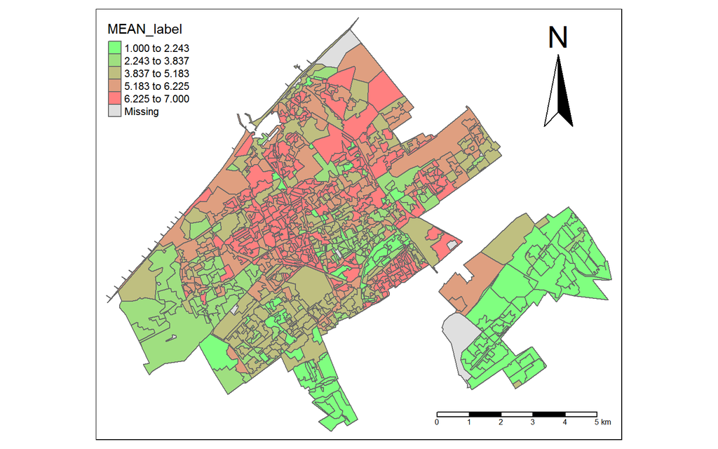

## Raster data

- Hokjes (meestel vierkant)
- Resolutie (30x30m vs. 5x5km)
- Satellieten/aerial data (hoe hoog staan ze)
- Extra dimensie: tijd (hoe hoger hoe vaker)

[interactive chart not shown]

## Layers

- Lagen kaart
- Over elkaar heen plotten
- Zoveel als je wil
- Raster & Vector door elkaar
- Pas op: Projectie

## Geoprocessing Tools

- Aggregeren (pc5 -> pc4)
- Join (van 2 -> 1 layer)
- Reproject (de ene laag zoals een andere)
- Etc

## Toekomst

- Big data
- Steeds meer data
- Meer satellieten
- We kunnen steeds meer meten
- **Visualiseren**

## Voorbeeld: Sentinal 5

- Trace gases (bv: NO2, ozon, formaldehyde, SO2, methaan, CO, aerosolen)
- Resolutie 7 km × 3.5 km / dagelijks!

[interactive chart not shown]

## Zelf aan de slag

- Den Haag
- Energielabels (vector)
- Gezondheid van vegetatie (raster)

## Files

- https://github.com/evandermeijde/Kennissessie_R_GIS_Den_Haag
- http://rpubs.com/evandermeijde/DenHaagExploreGISinR
- http://rpubs.com/evandermeijde/KennisSessieRinGIS
- "/Dropbox (FourPoints)/Projecten/Gemeente Den Haag/GIS in R/LandSat"
- http://www.esa.int/Our_Activities/Observing_the_Earth/Copernicus/Sentinel-5P/Introducing_Sentinel-5P